# Homework 2

Dima Galat

23 October 2016

## Question 1

Creating histograms for quantitative variables

- This is the histogram that you requested:

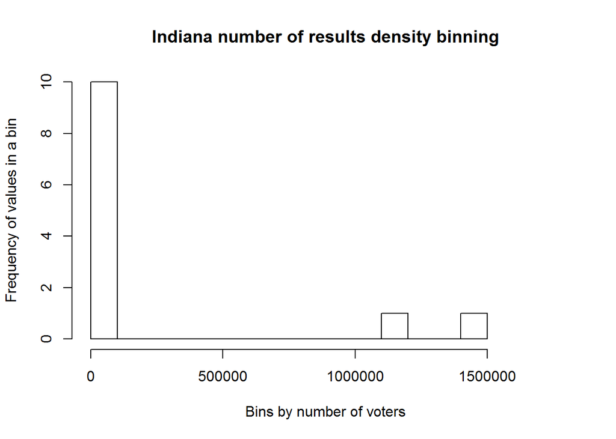

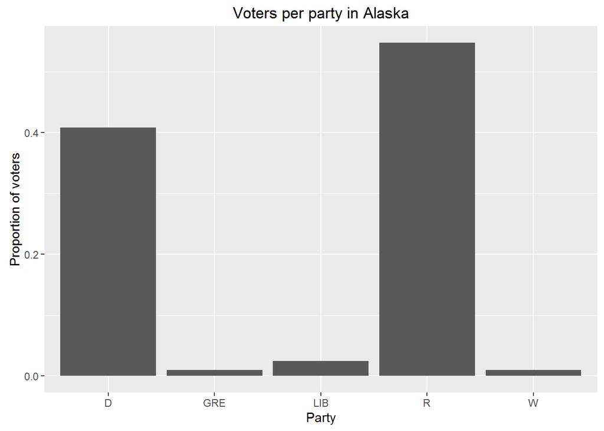

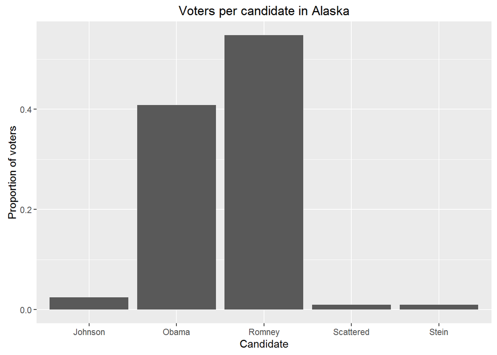

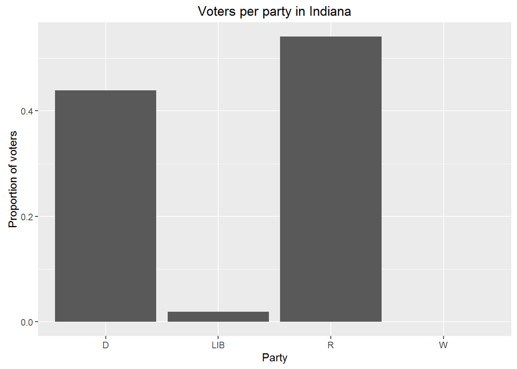

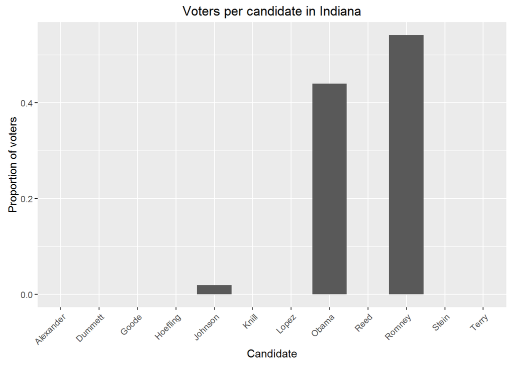

## Question 2

Creating box and scatter plots for quantitative variables

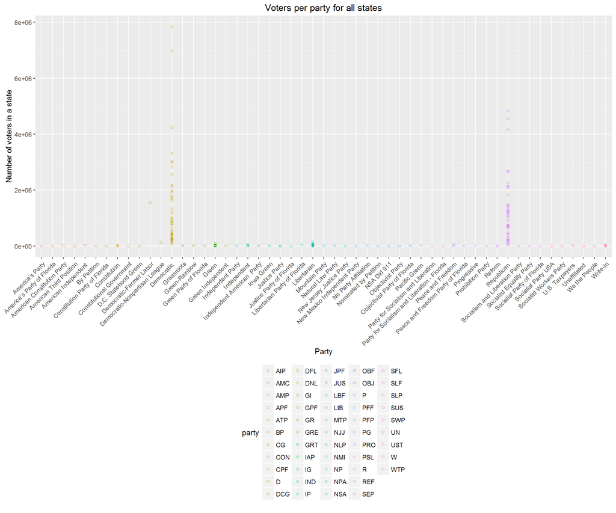

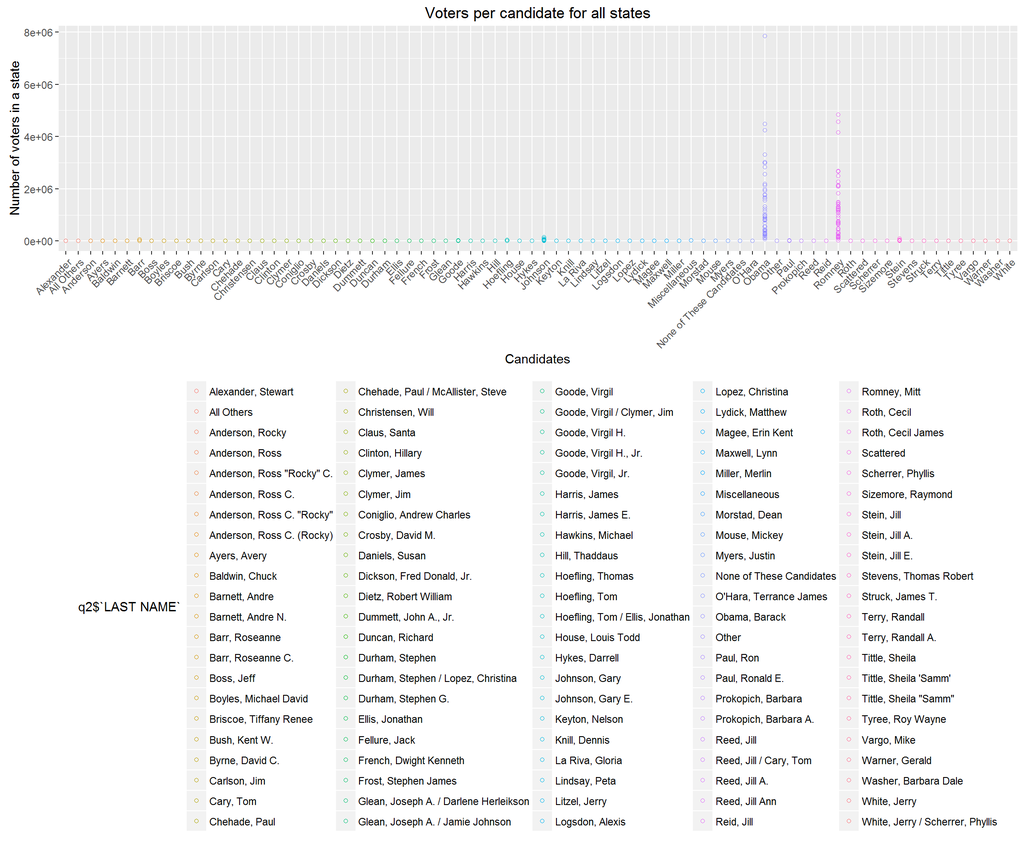

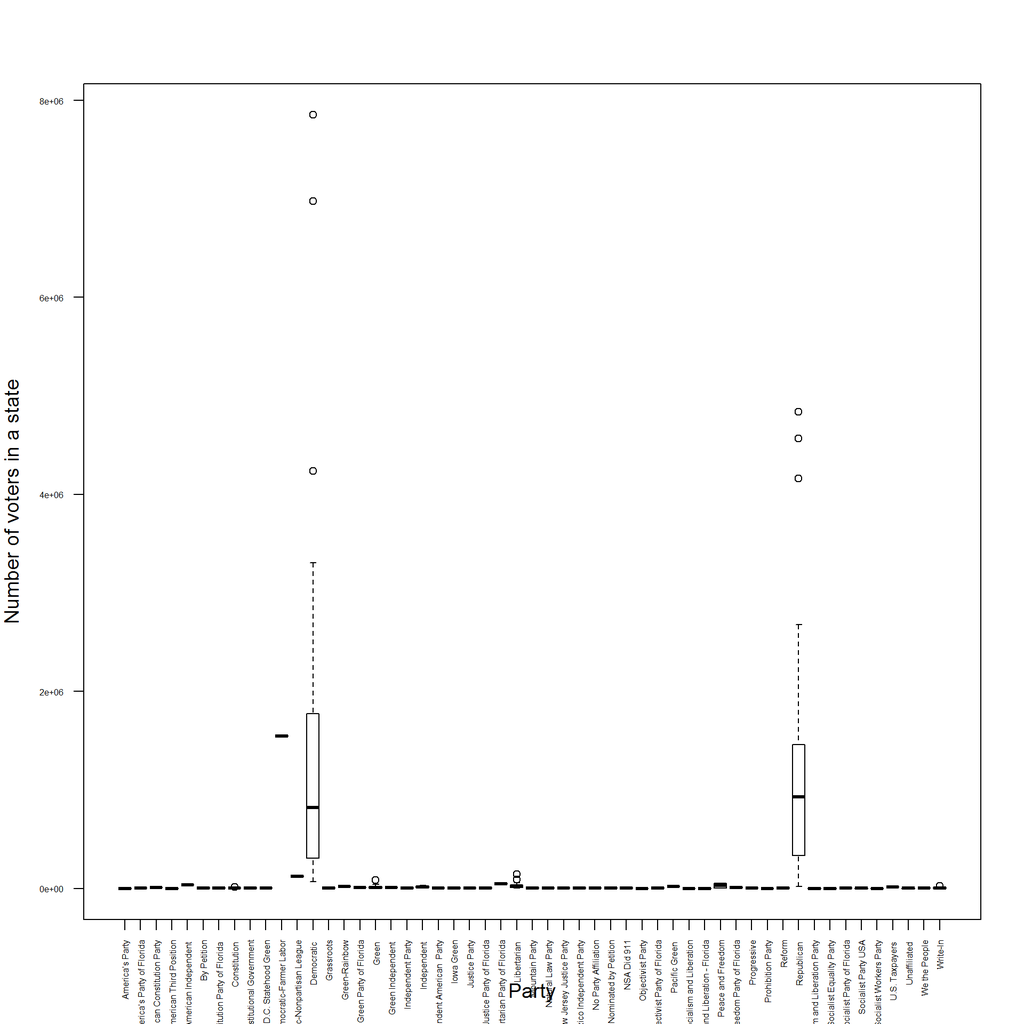

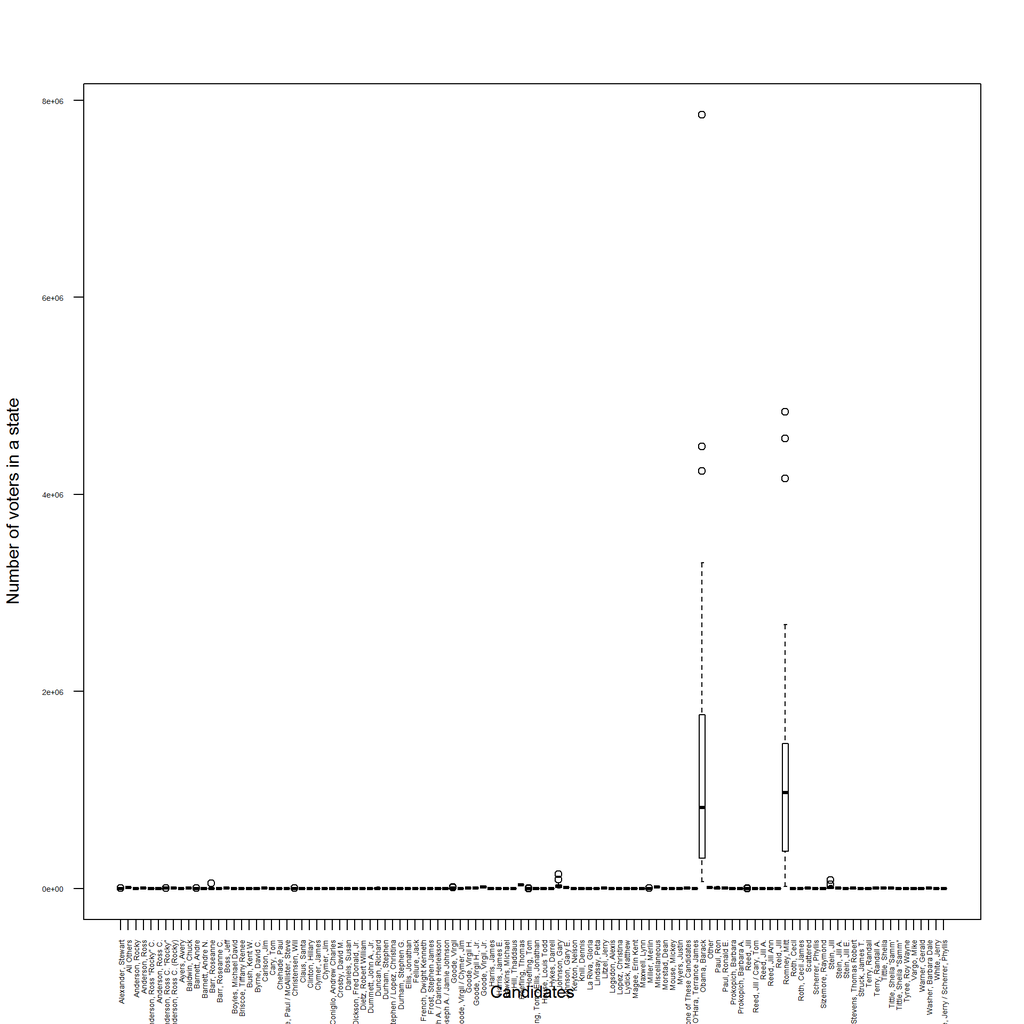

## Question 3

Create an overlay based on party red and blue lines as shown in Lynda.com exercise

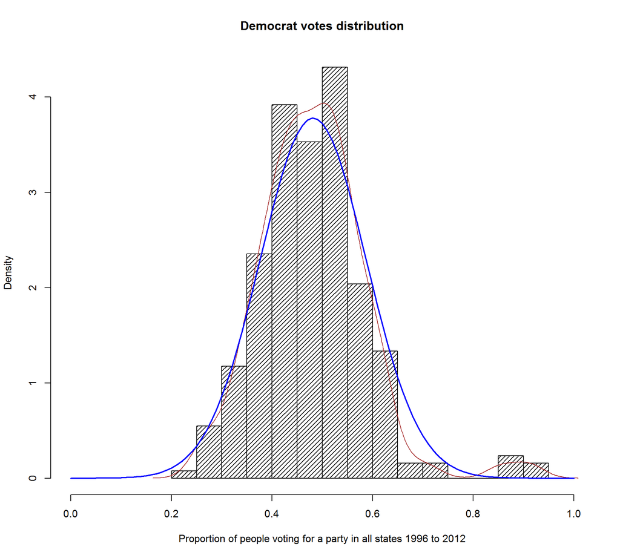

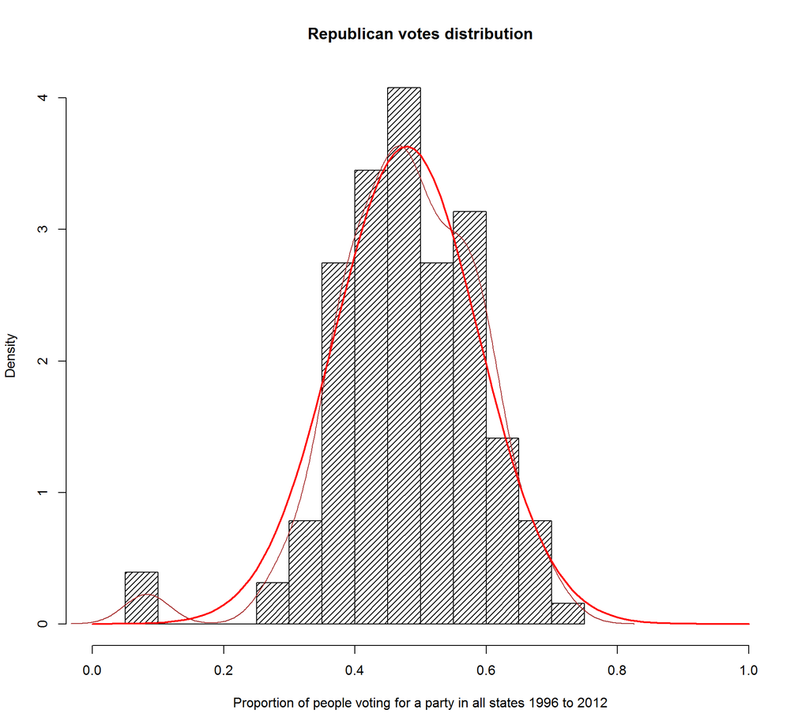

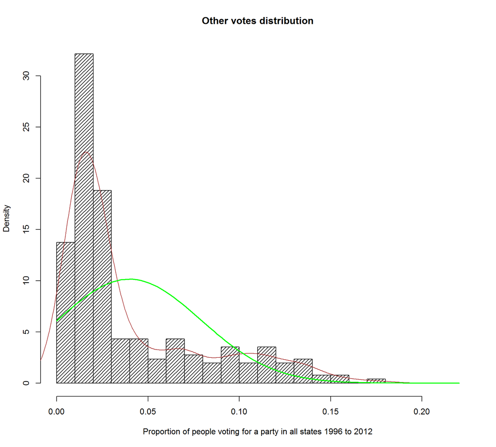

## Question 4

Calculate the frequencies of wins for each party win with all states.

```
## Number of republican wins: 24
```

```
## Number of democrat wins: 27
```

## Question 5

Create a summary using descriptive statistics off voter turnout in all states. Return the values of percentage for each party.

```
## Democratic turnout summary:
```

```
##    Min. 1st Qu.  Median    Mean 3rd Qu.    Max.
##  0.0000  0.3934  0.4789  0.4675  0.5698  0.8976
```

```
## Republican turnout summary:
```

```
##    Min. 1st Qu.  Median    Mean 3rd Qu.    Max.
##  0.0000  0.3791  0.4678  0.4519  0.5693  0.7106
```

```
## Other turnout summary:
```

```
##     Min.  1st Qu.   Median     Mean  3rd Qu.     Max.
## 0.005455 0.018430 0.028750 0.080640 0.057580 1.000000
```

## Question 6

Using a single proportion: Hypothesis test and confidence interval

Lynda shows an example for comparing independent samples, whereas we only have one sample, since democrats and republican votes are not independent. We could’ve used the function below, but it would’ve been incorrect.

```r
prop.test(x, n, p = 0.5, conf.level = 0.95, alternative = "two.sided")
```

```
##
##  1-sample proportions test with continuity correction
##
## data:  x out of n, null probability 0.5
## X-squared = 0.078431, df = 1, p-value = 0.7794
## alternative hypothesis: true p is not equal to 0.5
## 95 percent confidence interval:
##  0.3315787 0.6140026
## sample estimates:
##         p
## 0.4705882
```

Hence, I wrote some code to do a Binomal Proportion test that makes sense here.

```
## Accept Ho, Not enough evidence to reject Ho at 5%
```

- Errors for extra credit

Type 1 error, that we reject H0, given that H0 is true- will be used, if we reject NULL

Type 2 error, rejecting Ha, given that Ha is true; same as the probability that observed value is not the rejection region when Ha is true

```
## The value of the alpha is 5%
```

```
## The value of the beta is 29.9%
```

## Question 7

Using a single mean: Hypothesis test and confidence interval

Claim: Democrates will lose the election with mu < 0.5

Null Hypothesis is that Republicans will score 50% of voters, therefore win

Alternative hypothesis: Republicans will get less than 50 % of voters and lose

Test to perform at alpha 5% significance:

```
Ho: mu = 0.5001

Ha: mu < 0.5001
```

```
## [1] -1.76131
```

```
## Statistical evidence suggests that Ho cannot be rejected at 5%, because the sample does not significantly deviate from mu
```

## Question 8

Using a single categorical variable: One sample chi-square test

This is a goodness of fit test, we are testing that votes are equally distributed between parties, this is an equivalent of saying mu = 0.5 Ho: votes are equally distributed between both parties Ha: votes are not equally distributed between both parties

```
##
##  Chi-squared test for given probabilities
##
## data:  voters
## X-squared = 1.5474, df = 1, p-value = 0.2135
```

```
## Statistical evidence suggests that Ho cannot be rejected at 5%, because the sample does not significantly deviate from mu=0.5
```

## Question 9

Create a decision tree in your state based on voter turnout.

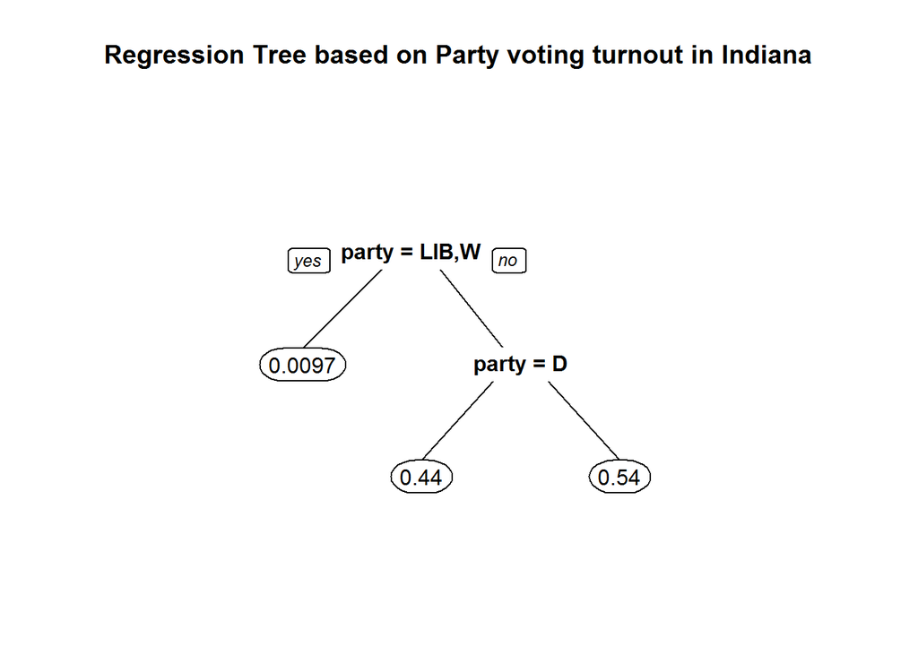

## Question 10

Create a scatter plot with liner regression line to show each counties voting pattern for each party.

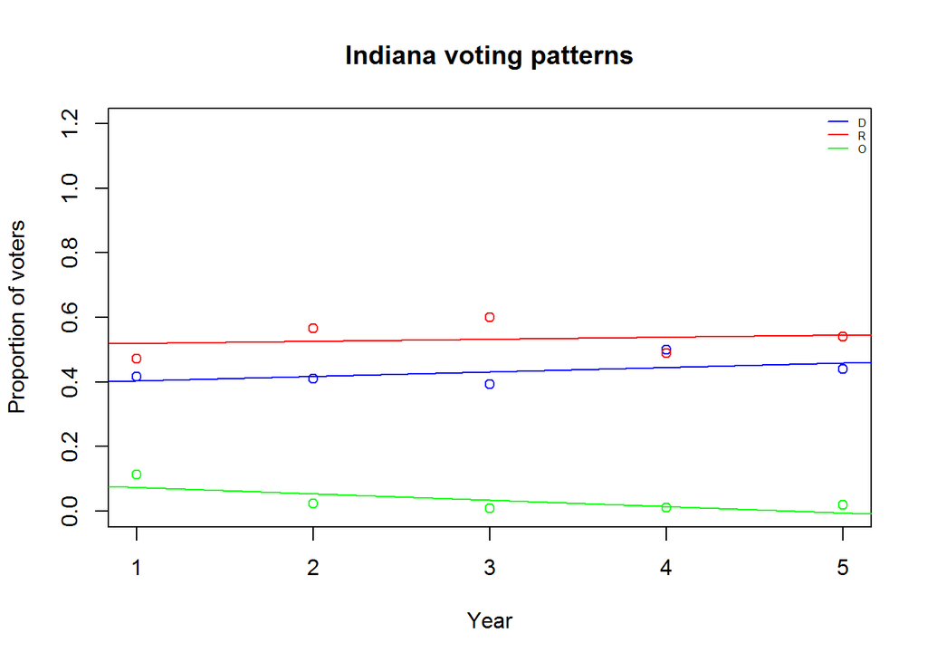